# 10.7 演習問題

2019/6/23

# (1)

## (a)

$$\begin{eqnarray}
& & \frac{1}{|C_k|}\sum_{i,i'\in{C_k}}\sum_{j=1}^p(x_{ij}-x_{i'j})^2 \\
& = & \frac{1}{|C_k|}\sum_{i\in{C_k}} \left\{ {\sum_{j=1}^p(x_{ij}-x_{1j})^2} + {\sum_{j=1}^p(x_{ij}-x_{2j})^2}
+ \cdots + {\sum_{j=1}^p(x_{ij}-x_{|C_k|j})^2} \right\} \\
& = & \frac{1}{|C_k|}\sum_{i\in{C_k}} \sum_{j=1}^p
\left\{ |C_k|x_{ij}^2 -2(x_{1j} + x_{2j} + \cdots + x_{|C_k|j})x_{ij} + (x_{1j}^2 + x_{1j}^2 + \cdots +x_{|c_k|j}^2) \right\}
(∵二乗を展開) \\
& = &
\sum_{i\in{C_k}} \sum_{j=1}^p
\left( x_{ij}^2 -2\frac{1}{|C_k|}\sum_{i'=1}^{|C_k|}x_{i'j} x_{ij}
\right)
+
\sum_{i\in{C_k}} \sum_{j=1}^p
\left(
\frac{\sum_{i\in{C_k}}x_{ij}^2}{|C_k|}
\right) \\
& = &
\sum_{i\in{C_k}} \sum_{j=1}^p
\left( x_{ij}^2 -2\bar{x}_{kj} x_{ij} + \bar{x}_{kj}^2
\right)
+
\sum_{i\in{C_k}} \sum_{j=1}^p
\left(
\frac{\sum_{i\in{C_k}}x_{ij}^2}{|C_k|} - \bar{x}_{kj}^2
\right)
(∵\bar{x}_{kj}^2を挿入) \\
& = &
\sum_{i\in{C_k}}\sum_{j=1}^p(x_{ij}-\bar{x}_{kj})^2
+ \sum_{i\in{C_k}}\sum_{j=1}^p(x_{ij}-\bar{x}_{kj})^2 \\
& = &
2\sum_{i\in{C_k}}\sum_{j=1}^p(x_{ij}-\bar{x}_{kj})^2
\end{eqnarray}$$

## (b)

まず,最適化問題(10.11)が割り当てステップによって減少することを示す.
$x_i\in C_k$ だったのがStep2(b)で$x_{i} \in C_{k'}$ に移るとする.
これは,各$x_{ij}$はもっとも近い重心に割り当てられるため,
$$\sum_{i\in{C_k}}\sum_{j = 1}^p (x_{ij} - \bar{x}_{k'j})^2 ≤ \sum_{i\in{C_k}}\sum_{j = 1}^p (x_{ij} - \bar{x}_{kj})^2$$
が成立し,その距離が影響する(10.11)は減少する.
次に再計算ステップでも減少することを証明する.
まず$f(v_{k1},\dots,v_{kj},\dots,v_{kp}) = \sum_{i\in{C_k}}\sum_{j = 1}^p (x_{ij} - v_{kj})^2$を最小とする $\forall j=1,\dots,p$,$v_{kj}$を見つける.
最小値では微分係数は0になるので,
$$\frac{\partial f}{\partial v_{kj}} = \sum_{i\in{C_k}}2 (x_{ij} - v_{kj}) =0$$
よって,
$$v_{kj}=\frac{1}{|C_k|}\sum_{i\in{C_k}}x_{ij} = \bar{x}_{kj}$$
よって,$v_{kj}$は重心の定義{x}_{kj}に一致する.
よって前の重心から、新しい重心に移ることで$\sum_{i\in{C_k}}\sum_{j = 1}^p (x_{ij} - v_{kj})^2$は減少する.
これの合計である$\sum_{k=1}^{K} \frac{1}{|C_k|}\sum_{i,i'\in{C_k}}\sum_{j=1}^p(x_{ij}-x_{i'j})^2$も再計算ステップで減少する.

# (2)

## (a)

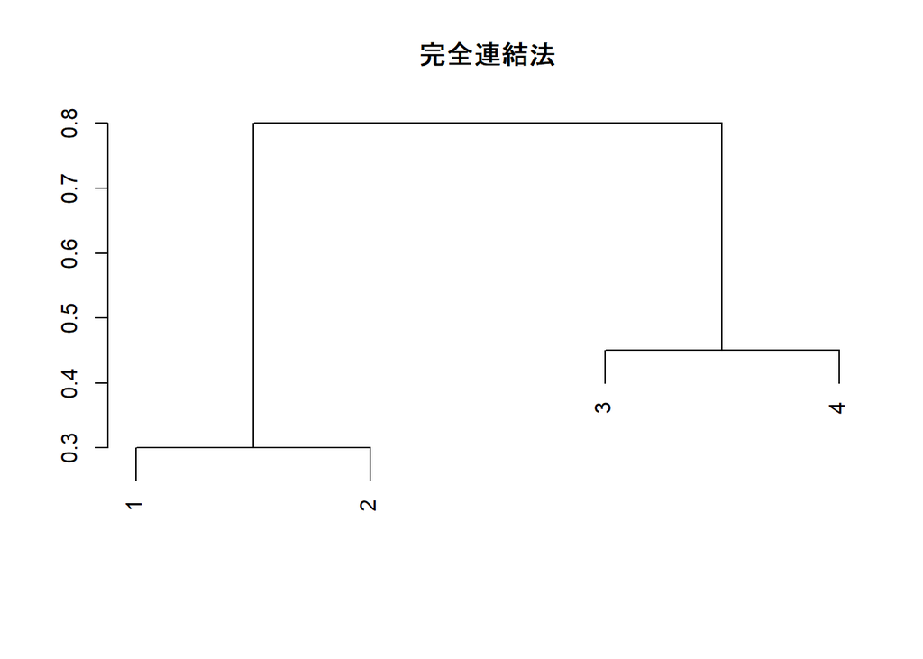

```r
dmat = matrix(c(0,0.3,0.4,0.7,0.3,0,0.5,0.8,0.4,0.5,0,0.45,0.7,0.8,0.45,0),4,4)
hc.2c=hclust(as.dist(dmat),method="complete")
plot(hc.2c, main="完全連結法",
xlab="",sub="",ylab="")
```

## (b)

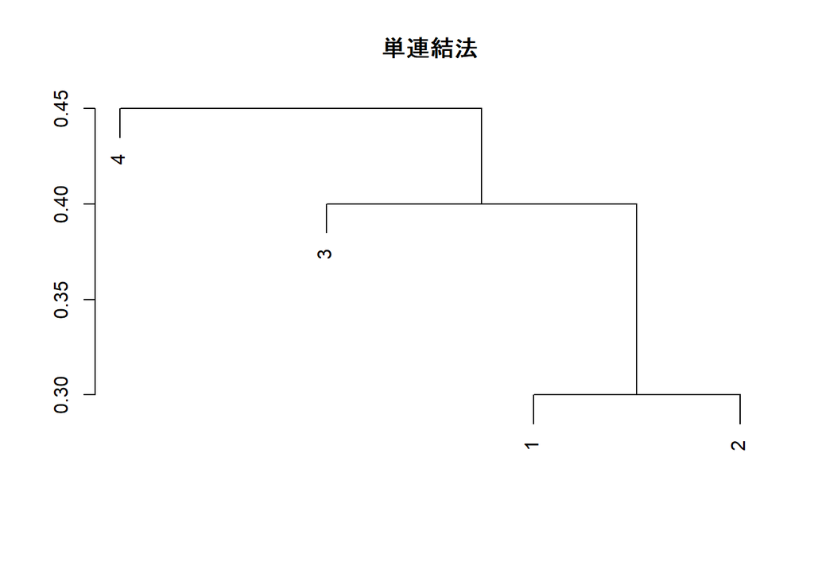

```r
hc.2s=hclust(as.dist(dmat),method="single")
plot(hc.2s, main="単連結法",
xlab="",sub="",ylab="")
```

## (c)

高さ0.7の切断で{1,2},{3,4}のクラスターを得る.

## (d)

高さ0.41の切断で{1,2,3},{4}のクラスターを得る.

## (e)

```r
# dendoextendを使用
library("dendextend")
```

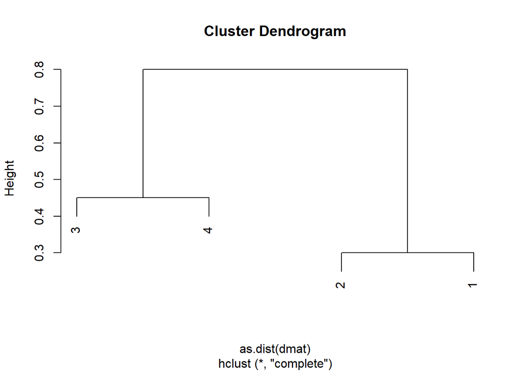

```r
den2e <- dendextend::rotate(hc.2c,c(3,4,2,1))
plot(den2e)
```

# (3)

## (a)

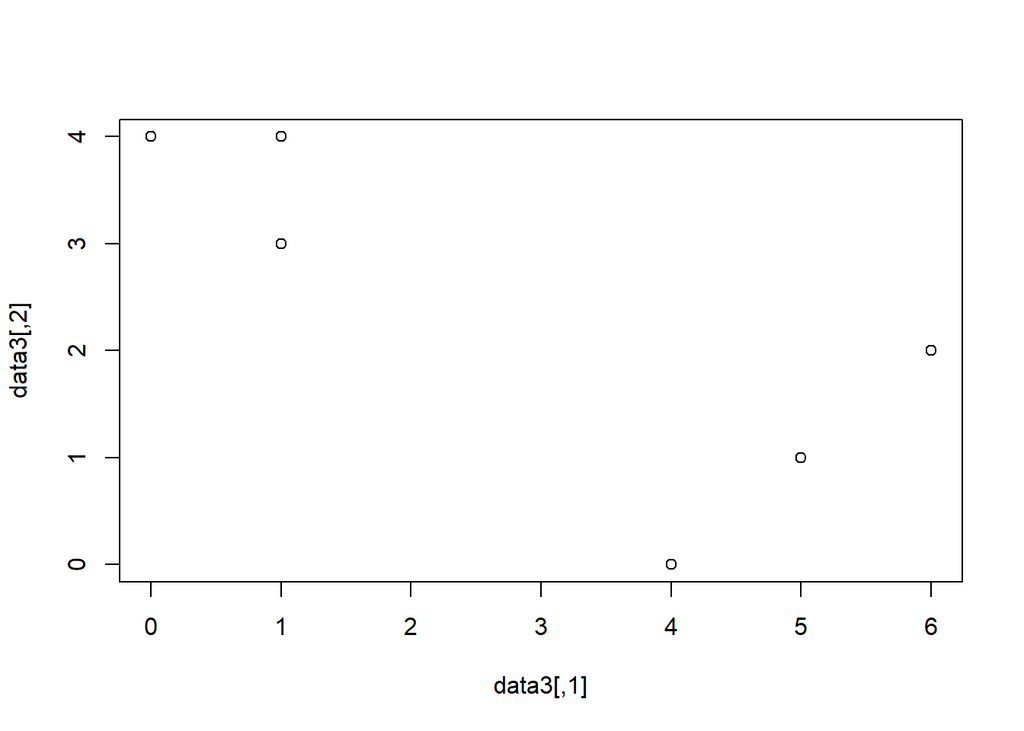

```r
data3 = matrix(c(1, 1, 0, 5, 6, 4, 4, 3, 4, 1, 2, 0),6,2)
plot(data3)
```

## (b)

```r
set.seed(2)
# ラベルをランダムに割り当てる
label = sample(c(1,2),6,T)
rownames(data3)=label
data3
```

```
##   [,1] [,2]
## 1    1    4
## 2    1    3
## 2    0    4
## 1    5    1
## 2    6    2
## 2    4    0
```

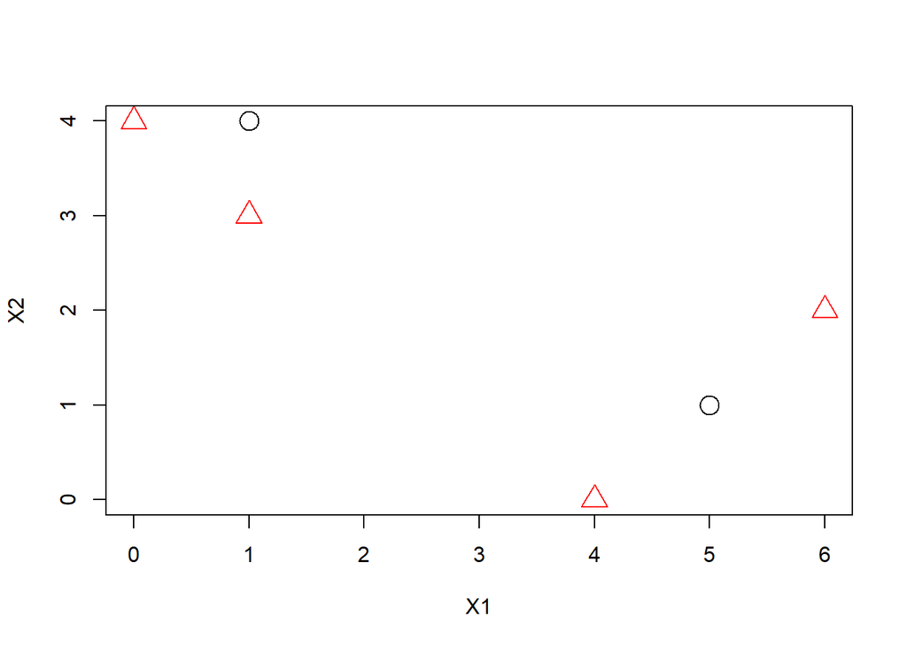

```r
plot(data3,col=(label),main="",
xlab="X1",ylab="X2",pch=label,cex=2)
```

## (c)

```r
#クラスタ1の重心を計算する.
cluster1_jusin = c(mean(data3[,1][rownames(data3)==1]),
mean(data3[,2][rownames(data3)==1]))
#クラスタ2の重心を計算する.
cluster2_jusin = c(mean(data3[,1][rownames(data3)==2]),
mean(data3[,2][rownames(data3)==2]))
```

## (d)

```r
for (i in 1:6) {
  dist1 = sum((data3[i,]-cluster1_jusin)^2)
  dist2 = sum((data3[i,]-cluster2_jusin)^2)
  if (dist1<dist2){
    label[i] = 1
  }
  else{
  label[i] = 2
  }
}
rownames(data3)=label
data3
```

```
##   [,1] [,2]
## 2    1    4
## 2    1    3
## 2    0    4
## 1    5    1
## 1    6    2
## 2    4    0
```

## (e)

```r
for(j in 1:4){
  cluster1_jusin = c(mean(data3[,1][rownames(data3)==1]),
  mean(data3[,2][rownames(data3)==1]))
  cluster2_jusin = c(mean(data3[,1][rownames(data3)==2]),
  mean(data3[,2][rownames(data3)==2]))

  for (i in 1:6) {
    dist1 = sum((data3[i,]-cluster1_jusin)^2)
    dist2 = sum((data3[i,]-cluster2_jusin)^2)
    if (dist1<dist2){
    label[i] = 1
    }
    else{
    label[i] = 2
    }
  }
  rownames(data3)=label
  data3
  }
```

## (f)

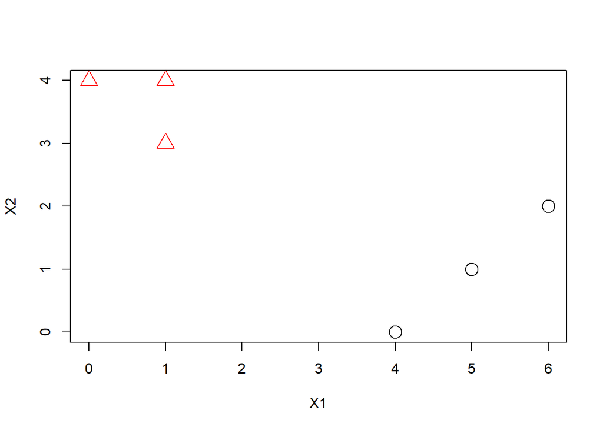

```r
plot(data3,col=(label),main="",
xlab="X1",ylab="X2",pch=label,cex=2)
```

# (4)

## (a)

以下、dist(x,y)はxとyの非類似度を表す関数である.  
単連結法では,min[dist({1,2,3},{4,5})]の高さで結合する.  
完全連結法では,max[dist({1,2,3},{4,5})]の高さで結合する.  
よって,完全連結法のほうが高い位置で統合される.

## (b)

同じ高さで結合する.

# (7)

```r
sd = scale(USArrests)
c = 1-cor(sd)
c
```

```
##             Murder   Assault  UrbanPop      Rape
## Murder   0.0000000 0.1981267 0.9304274 0.4364212
## Assault  0.1981267 0.0000000 0.7411283 0.3347588
## UrbanPop 0.9304274 0.7411283 0.0000000 0.5886588
## Rape     0.4364212 0.3347588 0.5886588 0.0000000
```

```r
dMA = mean((sd[,1]-sd[,2])^2)
dMU = mean((sd[,1]-sd[,3])^2)
dMR = mean((sd[,1]-sd[,4])^2)
dAU = mean((sd[,2]-sd[,3])^2)
dAR = mean((sd[,2]-sd[,4])^2)
dUR = mean((sd[,3]-sd[,4])^2)

d = matrix(c(0,dMA,dMU,dMR,dMA,0,dAU,dAR,dMU,dAU,0,dUR,dMR,dAR,dUR,0),4,4)
d
```

```
##           [,1]      [,2]     [,3]      [,4]
## [1,] 0.0000000 0.3883283 1.823638 0.8553855
## [2,] 0.3883283 0.0000000 1.452611 0.6561272
## [3,] 1.8236377 1.4526115 0.000000 1.1537712
## [4,] 0.8553855 0.6561272 1.153771 0.0000000
```

```r
d/c
```

```
##          Murder Assault UrbanPop Rape
## Murder      NaN    1.96     1.96 1.96
## Assault    1.96     NaN     1.96 1.96
## UrbanPop   1.96    1.96      NaN 1.96
## Rape       1.96    1.96     1.96  NaN
```